# Profile

## Question: What is the average daily activity pattern?

### 1.Make a time series plot (i.e. type = “l”) of the 5-minute interval (x-axis) and the average number of steps taken, averaged across all days (y-axis)

### 2.Which 5-minute interval, on average across all the days in the dataset, contains the maximum number of steps?

```r
activity3 <- group_by(activity, interval)
activity3 <- na.omit(activity3)
avgsteps_interval <- summarise(activity3, avg_steps = mean(steps))
```

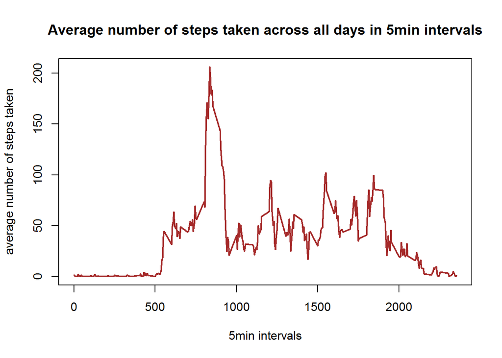

```r
#png("plot2.png",width = 480, height = 480)
plot(avgsteps_interval,type = 'l', col = 'brown',lwd=2,
     main = "Average number of steps taken across all days in 5min intervals",
     xlab = "5min intervals",ylab = "average number of steps taken")
```

```r
dev.off()
```

Which 5-minute interval, on average across all the days in the dataset, contains the maximum number of steps?

```r
maxsteps <- filter(avgsteps_interval, avg_steps == max(avg_steps))
cat(sprintf("At %sth 5min interval, the maximum number of %f steps are found on average on all days in the data set. \n", maxsteps$interval, maxsteps$avg_steps))
```

```
## At 835th 5min interval, the maximum number of 206.169811 steps are found on average on all days in the data set.
```

## Managing Missing Values

### Calculate and report the total number of missing values in the dataset (i.e. the total number of rows with NAs)

```r
missing_steps <- sum(is.na(activity$steps))
missing_date <- sum(is.na(activity$date))
missing_interval <- sum(is.na(activity$interval))

cat(sprintf("Total number of missing values in steps field =  %s\n", missing_steps))
```

```
## Total number of missing values in steps field =  2304
```

```r
cat(sprintf("Total number of missing values in date field =  %s\n", missing_date))
```

```
## Total number of missing values in date field =  0
```

```r
cat(sprintf("Total number of missing values in interval field =  %s\n",missing_interval))
```

```
## Total number of missing values in interval field =  0
```

```r
#create new dataset with removed NA
activity4<- activity
avgsteps <- summarise(activity3, mean_steps = mean(steps), median_steps = median(steps))
activity4$steps[is.na(activity4$steps)] <- tapply(activity4$steps, activity4$interval, mean, na.rm = TRUE)
```

```r
#check for any missing values
sum(is.na(activity4))
```

```
## [1] 0
```

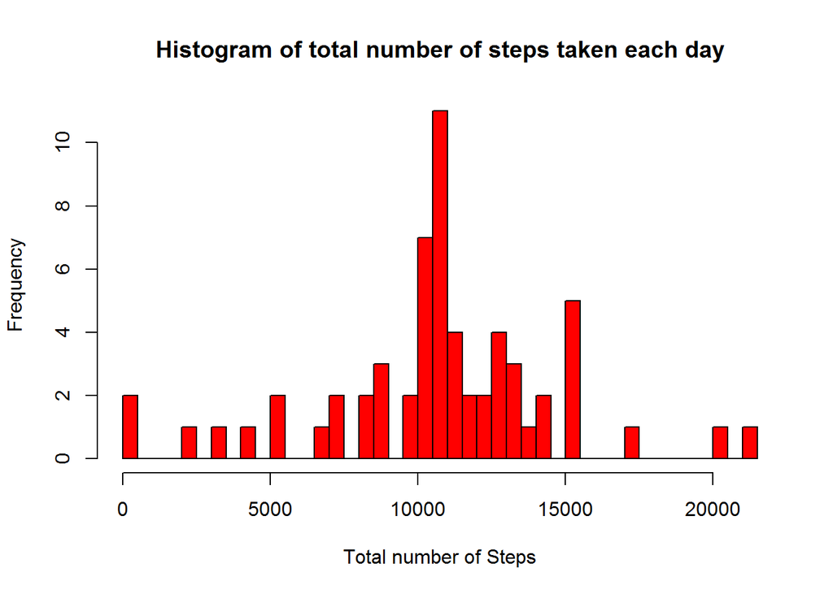

```r
activity5 <- group_by(activity4, date)
dailysteps_afms <- summarise(activity5,total_steps = sum(steps))

#png("plot3.png",width = 480, height = 480)
hist(dailysteps_afms$total_steps,breaks=length(dailysteps_afms$total_steps)-1,
     col = 'red', main = "Histogram of total number of steps taken each day",
     xlab = "Total number of Steps",plot = T)
```

```r
dev.off()
```

```r
new_mean <-mean(dailysteps_afms$total_steps)
new_median <-median(dailysteps_afms$total_steps)

cat(sprintf("The new mean is=  %s\n", new_mean))
```

```
## The new mean is=  10766.1886792453
```

```r
cat(sprintf("The new median is =  %s\n", new_median))
```

```
## The new median is =  10766.1886792453
```

## Question:Are there differences in activity patterns between weekdays and weekends?

For this part the weekdays() function may be of some help here. Use the dataset with the filled-in missing values for this part.

```r
###Create a new factor variable in the dataset with two levels - “weekday” and “weekend” indicating whether a given date is a weekday or weekend day
###Make a panel plot containing a time series plot (i.e. type = “l”) of the 5-minute interval (x-axis) and the average number of steps taken, averaged across all weekday days or weekend days (y-axis). See the README file in the GitHub repository to see an example of what this plot should look like using simulated data.
activity6<- activity5
activity6$wdays <- weekdays(as.Date(activity6$date))
activity6 <-mutate(activity6, wk.factor = factor((wdays == "Sunday" | wdays == "Saturday"),levels = c(FALSE,TRUE),
                                     labels = c("weekdays","weekends")))
MeanStep_byIntervalByWkday <- aggregate(steps ~ interval + wk.factor, data=activity6, FUN="mean")
```

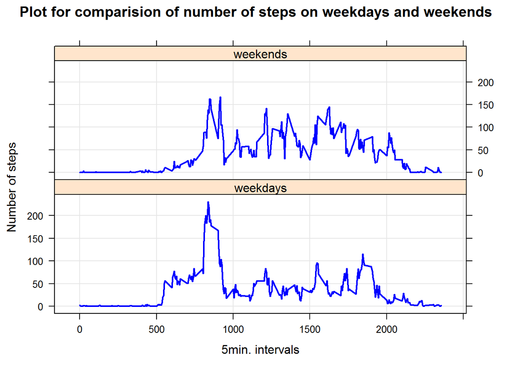

```r
#png("plot4.png",width = 480, height = 480)
xyplot(steps ~ interval | wk.factor, data=MeanStep_byIntervalByWkday, type="l", grid=T, layout=c(1,2),
       main="Plot for comparision of number of steps on weekdays and weekends",
       xlab = "5min. intervals", ylab = "Number of steps",lwd = 2,col = "blue")
```